# Assignment 6

Colella, Williams, and Williams

June 13, 2020

### EDA General

*The Units Sold Distribution tab shows the distribution of Units Sold. The data is extremely imbalanced. There are 18,963 records with 0 units sold. There are 772 records with one or more units sold.*

*The dataset has 0 missing values.*

#### DataStructure

```r
str(df)
```

```
## tibble [19,735 x 11] (S3: tbl_df/tbl/data.frame)
##  $ Date                 : POSIXct[1:19735], format: "2016-05-19" "2016-05-19" ...
##  $ Campaign_Name        : chr [1:19735] "Targeted Conversion Campaign" "Targeted Conversion Campaign" "Targeted Conversion Campaign" "Targeted Conversion Campaign" ...
##  $ Content_Category     : Factor w/ 8 levels "Advertising Nets",..: 1 1 1 1 1 1 1 1 1 1 ...
##  $ Creative_Product     : Factor w/ 2 levels "Desktop","Laptop": 2 1 1 2 1 2 1 2 2 1 ...
##  $ Creative             : Factor w/ 8 levels "Best value Tab",..: 8 5 3 3 1 1 2 8 3 5 ...
##  $ Creative_Size        : Factor w/ 6 levels "120x600","160x600",..: 3 3 3 3 3 3 2 2 2 2 ...
##  $ Website_Network_Name : Factor w/ 27 levels "Adconion Media Group",..: 3 3 3 3 3 3 3 3 3 3 ...
##  $ Impressions_Delivered: num [1:19735] 2169 1345 2253 2281 2193 ...
##  $ Clicks_Recorded      : num [1:19735] 988 988 1087 1074 1041 ...
##  $ Media_Cost           : num [1:19735] 6.77 6.39 6.42 6.79 6.47 ...
##  $ Units_sold           : num [1:19735] 0 0 0 0 0 0 0 0 0 0 ...
```

#### View of Data

```r
head(df)
```

```
## # A tibble: 6 x 11
##   Date                Campaign_Name Content_Category Creative_Product Creative
##   <dttm>              <chr>         <fct>            <fct>            <fct>
## 1 2016-05-19 00:00:00 Targeted Con~ Advertising Nets Laptop           Super V~
## 2 2016-05-19 00:00:00 Targeted Con~ Advertising Nets Desktop          Save Mo~
## 3 2016-05-19 00:00:00 Targeted Con~ Advertising Nets Desktop          Better ~
## 4 2016-05-19 00:00:00 Targeted Con~ Advertising Nets Laptop           Better ~
## 5 2016-05-19 00:00:00 Targeted Con~ Advertising Nets Desktop          Best va~
## 6 2016-05-19 00:00:00 Targeted Con~ Advertising Nets Laptop           Best va~
## # ... with 6 more variables: Creative_Size <fct>, Website_Network_Name <fct>,
## #   Impressions_Delivered <dbl>, Clicks_Recorded <dbl>, Media_Cost <dbl>,
## #   Units_sold <dbl>
```

#### Units Sold Distribution

```r
units_sold_dist <- sqldf("select Units_sold, count(*) from df group by Units_sold")
units_sold_dist
```

```
##    Units_sold count(*)
## 1           0    18963
## 2           1      511
## 3           2      130
## 4           3       58
## 5           4       24
## 6           5       19
## 7           6       10
## 8           7        4
## 9           8        6
## 10          9        1
## 11         10        4
## 12         11        3
## 13         13        1
## 14         15        1
```

#### Missing Data

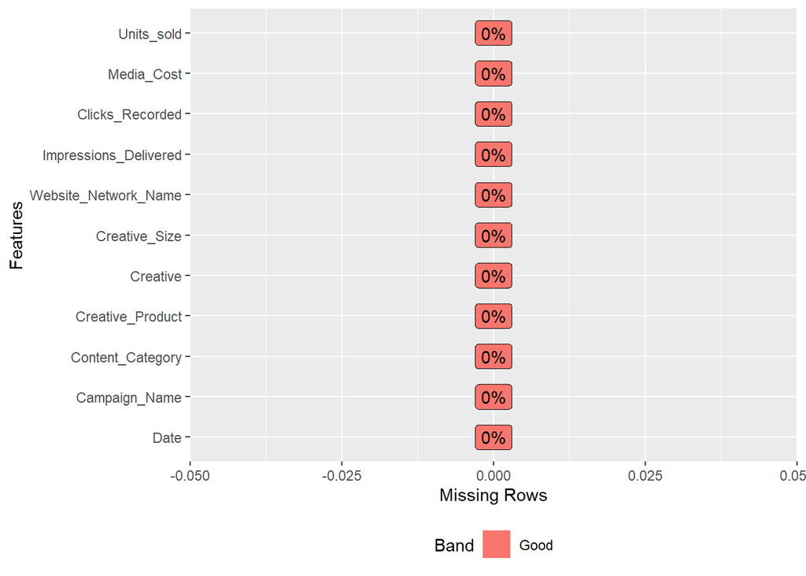

```r
plot_missing(df)
```

### EDA: Levels Distribution

*As can be seen on the Content_Category tab, Behavioral Targeting and Advertising Nets accounted for the bulk of the content categories. The advertising consisted of equal distributions between Laptops and Desktops. There was a nice mix of creative components with Best Value, Better Products, and the Save Money Green Logo at the top 3. The 728X90 banner ad size was the dominant ad dimension. The Collective Media network and the Microsoft DRIVEpm network were the top two networks that showed the display ads.*

#### Content_Category

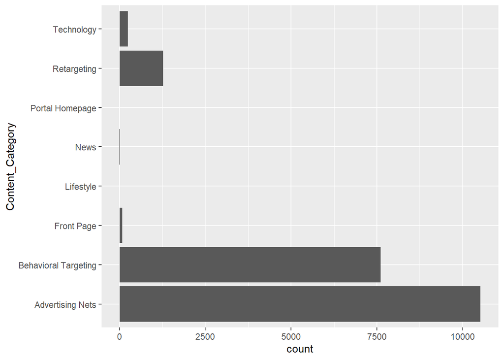

```r
bar1 <- ggplot(data = df) + geom_bar(mapping = aes(x = Content_Category)) + coord_flip()
bar1
```

#### Creative_Product

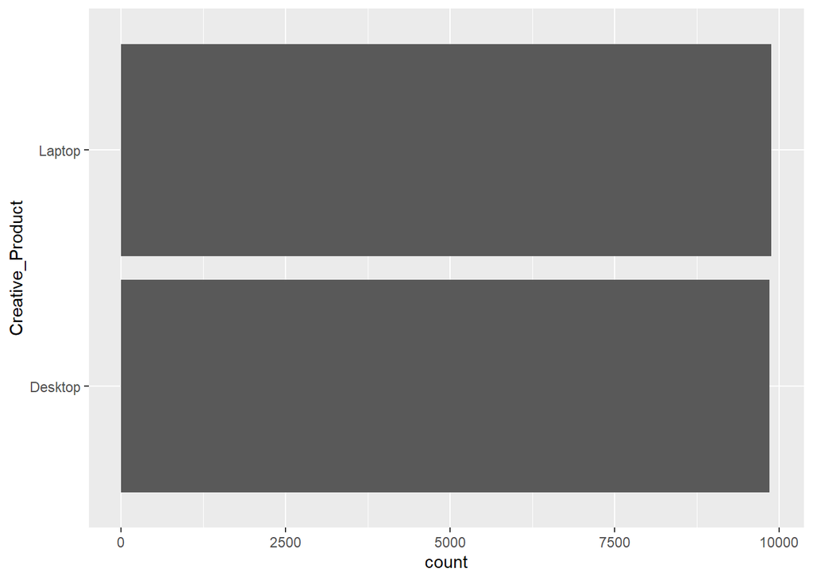

```r
bar2 <- ggplot(data = df) + geom_bar(mapping = aes(x = Creative_Product)) + coord_flip()
bar2
```

#### Creative

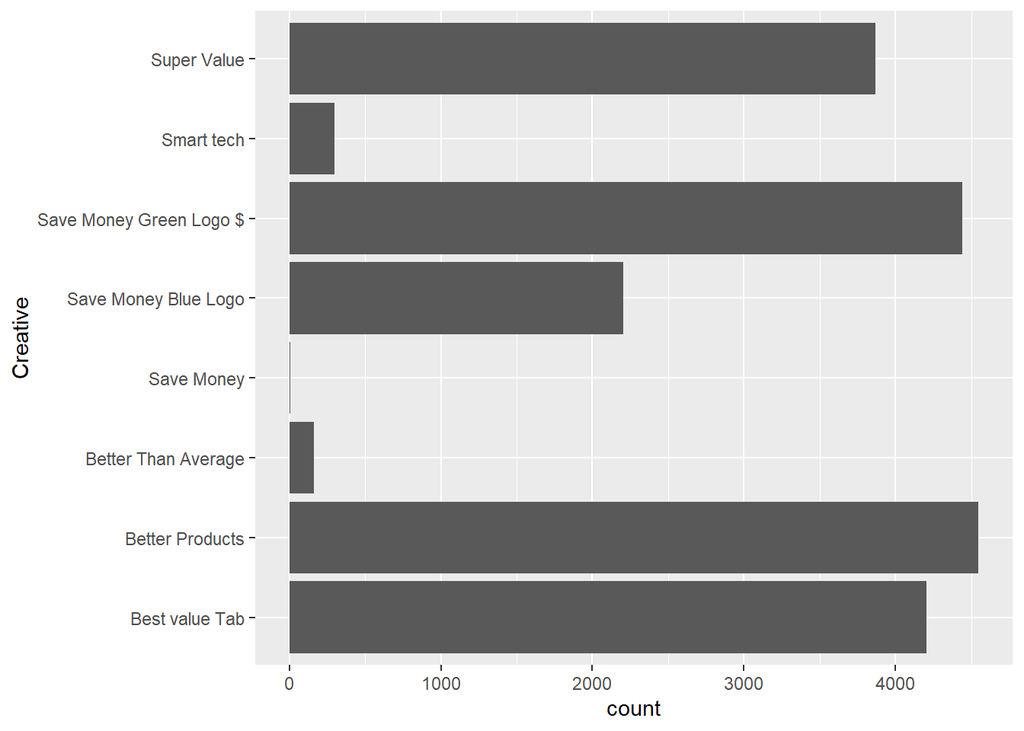

```r
bar3 <- ggplot(data = df) + geom_bar(mapping = aes(x = Creative)) + coord_flip()
bar3
```

#### Creative_Size

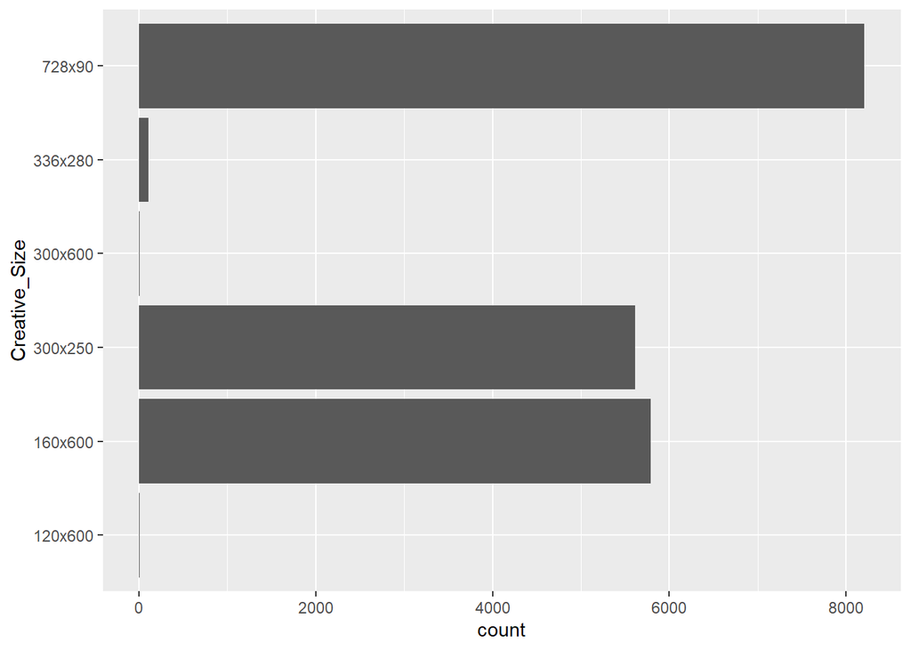

```r
bar4 <- ggplot(data = df) + geom_bar(mapping = aes(x = Creative_Size)) + coord_flip()
bar4
```

#### Website_Network_Name

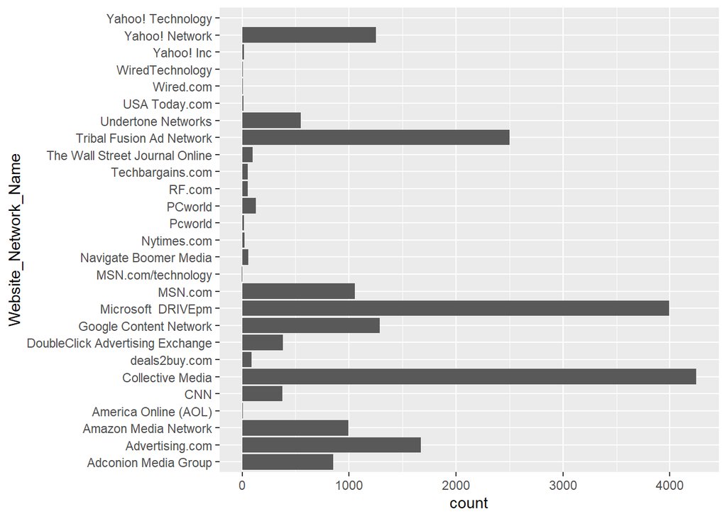

```r
bar5 <- ggplot(data = df) + geom_bar(mapping = aes(x = Website_Network_Name)) + coord_flip()
bar5
```

### EDA: Conversion,Click Through Plots

*For the time series charts, the number of daily click throughs were up and down between roughly 100,000 and 300,000. However, in August, there was a strong increase in ad click throughs. This indicates there could have been in increase in ad spend for this period. We would hope there was an increase in conversions during this period.*

*Viewing the Spend By Day tab, as suspected, you’ll see there was an increase in spend activity during August that affected the number of click throughs.*

#### Click Throughs By Day

```r
require(scales)
```

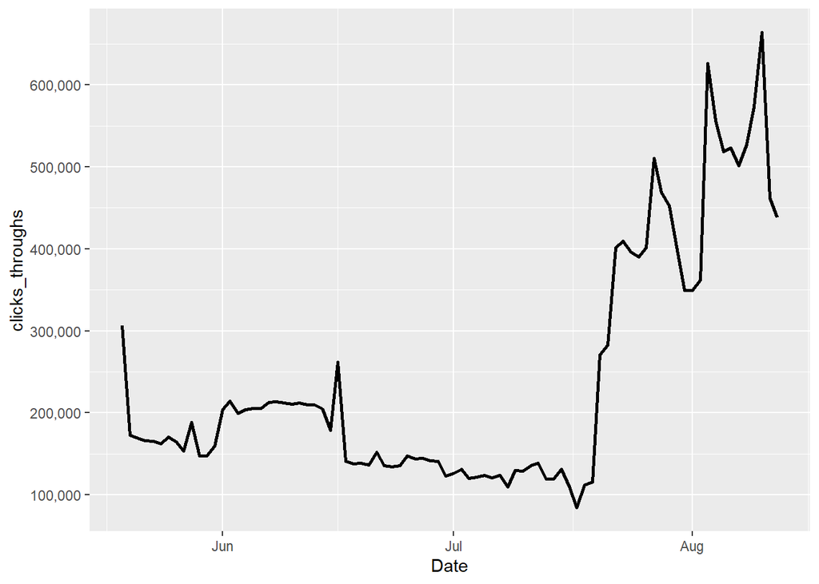

```r
clicks_by_day <- df %>% group_by(Date) %>% summarise(clicks_throughs = sum(Clicks_Recorded))
ggplot(data = clicks_by_day, aes(Date, clicks_throughs)) +
  geom_line(size=1) + scale_y_continuous(labels = comma)
```

#### Media Spend By Day

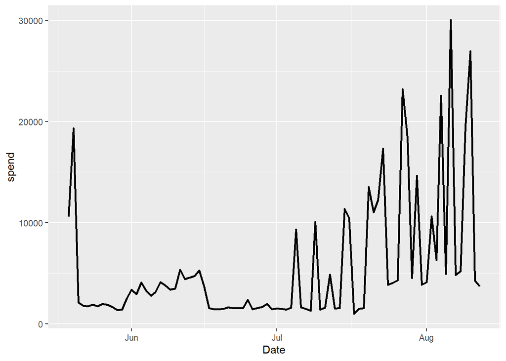

```r
spend_by_day <- df %>% group_by(Date) %>% summarise(spend = sum(Media_Cost))
ggplot(data = spend_by_day, aes(Date, spend)) +
  geom_line(size=1)
```

#### Conversions By Day

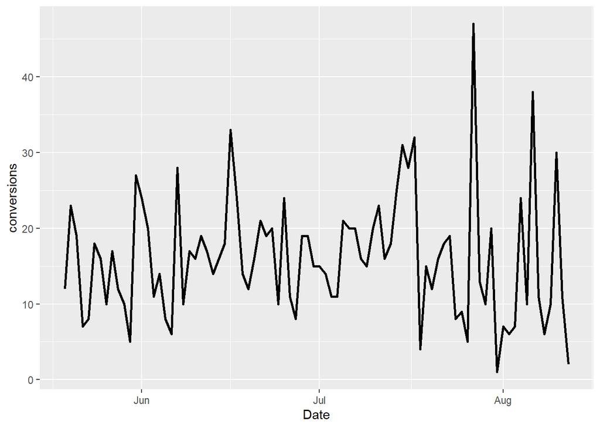

```r
conversions_by_day <- df %>% group_by(Date) %>% summarise(conversions = sum(Units_sold))
ggplot(data = conversions_by_day, aes(Date, conversions)) +
  geom_line(size=1)
```

### Modeling Approach: Conversions

*Several techniques were attempted. These attempts are highlighted in the “Optimize Rsquared for Conversions” section. We balanced the data by under sampling, over sampling, and both over and under sampling. This gave us three new datasets. We then implemented Poisson regression on each of these datasets. However the Rsquared value did not improve.*

*After these initial poor results, we considered how this model would eventually be used in production. We created Model 5. Knowing that most of the information that would be available to us in production would be categorical variables, we also wanted to see if we could incorporate the continuous variables. “Media_Cost” is a normalized variable at a per 1000 rate. This variable can be included in production since it ties closely to our categorical variables. Even though conversion rates are not provided in production, if you tie that metric to a website, you can create an interaction term, feature engineering. In production, we can impute the historical conversion rates by website, so we can incorporate it into our prediction on holdout data. Note that conversion rate is not used as an independent variable by itself: we are looking at the interaction between it and the categorical website variable.*

*Therefore, we believe the inclusion of media cost and the interaction between the website categorical variable and historical response rates is feasible.*

#### Model 1

```r
mod1 <- glm(Units_sold ~ Content_Category+Creative_Product+Creative+ Creative_Size+Website_Network_Name, data = df, family = "poisson")
1-(mod1$deviance/mod1$null.deviance)
```

```
## [1] 0.5114042
```

```r
summary(mod1)
```

```
##
## Call:
## glm(formula = Units_sold ~ Content_Category + Creative_Product +
##     Creative + Creative_Size + Website_Network_Name, family = "poisson",
##     data = df)
##
## Deviance Residuals:
##     Min       1Q   Median       3Q      Max
## -3.3764  -0.2605  -0.1641  -0.1199   9.0612
##
## Coefficients: (1 not defined because of singularities)
##                                                        Estimate Std. Error
## (Intercept)                                            -3.60085 1708.60769
## Content_CategoryBehavioral Targeting                   -1.55134    0.25133
## Content_CategoryFront Page                              1.63955    0.34930
## Content_CategoryLifestyle                             -14.33876 1550.87385
## Content_CategoryNews                                    0.29946    0.64849
## Content_CategoryPortal Homepage                         9.10457    1.07540
## Content_CategoryRetargeting                             0.58752    0.23943
## Content_CategoryTechnology                              5.16442    0.32964
## Creative_ProductLaptop                                  0.62290    0.07605
## CreativeBetter Products                                 0.61616    0.08710
## CreativeBetter Than Average                            -0.17358    0.22461
## CreativeSave Money                                     -0.41523    0.28263
## CreativeSave Money Blue Logo                            0.07480    0.10687
## CreativeSave Money Green Logo $                        -0.20594    0.13308
## CreativeSmart tech                                     -1.34286    1.00547
## CreativeSuper Value                                     0.04159    0.09328
## Creative_Size160x600                                   -0.03491 1708.60768
## Creative_Size300x250                                   -0.17157 1708.60768
## Creative_Size300x600                                   -2.56665 1708.60798
## Creative_Size336x280                                  -17.96879 2960.76286
## Creative_Size728x90                                     0.11909 1708.60768
## Website_Network_NameAdvertising.com                     1.78544    0.29573
## Website_Network_NameAmazon Media Network               -2.09601    0.48616
## Website_Network_NameAmerica Online (AOL)               -3.69186    1.03526
## Website_Network_NameCNN                                -0.59770    0.76864
## Website_Network_NameCollective Media                   -1.30198    0.23557
## Website_Network_Namedeals2buy.com                     -19.32487  353.68468
## Website_Network_NameDoubleClick Advertising Exchange    2.64878    0.29690
```

[output cut: 62 more lines]

```
## Website_Network_NameWired.com                          6.781 1.19e-11 ***
## Website_Network_NameWiredTechnology                    0.008 0.993322
## Website_Network_NameYahoo! Inc                         8.326  < 2e-16 ***
## Website_Network_NameYahoo! Network                     0.372 0.710219
## Website_Network_NameYahoo! Technology                     NA       NA
## ---
## Signif. codes:  0 '***' 0.001 '**' 0.01 '*' 0.05 '.' 0.1 ' ' 1
##
## (Dispersion parameter for poisson family taken to be 1)
##
##     Null deviance: 9717.4  on 19734  degrees of freedom
## Residual deviance: 4747.9  on 19689  degrees of freedom
## AIC: 6637.5
##
## Number of Fisher Scoring iterations: 15
```

#### Model 2

```r
mod2 <- glm(Units_sold ~ Content_Category+Creative_Product+Creative+ Creative_Size, data = df, family = "poisson")
1-(mod2$deviance/mod2$null.deviance)
```

```
## [1] 0.4259967
```

```r
summary(mod2)
```

```
##
## Call:
## glm(formula = Units_sold ~ Content_Category + Creative_Product +
##     Creative + Creative_Size, family = "poisson", data = df)
##
## Deviance Residuals:
##     Min       1Q   Median       3Q      Max
## -2.7410  -0.2428  -0.2168  -0.1711   9.3908
##
## Coefficients:
##                                       Estimate Std. Error z value Pr(>|z|)
## (Intercept)                          -16.42212  315.89600  -0.052  0.95854
## Content_CategoryBehavioral Targeting   0.02917    0.10270   0.284  0.77640
## Content_CategoryFront Page             4.82072    0.10627  45.362  < 2e-16 ***
## Content_CategoryLifestyle            -10.80533  346.04666  -0.031  0.97509
## Content_CategoryNews                   2.64702    0.58439   4.530 5.91e-06 ***
## Content_CategoryPortal Homepage        5.94559    0.21240  27.993  < 2e-16 ***
## Content_CategoryRetargeting            3.22506    0.07723  41.758  < 2e-16 ***
## Content_CategoryTechnology             1.67294    0.19640   8.518  < 2e-16 ***
## Creative_ProductLaptop                 0.65403    0.07017   9.320  < 2e-16 ***
## CreativeBetter Products                0.39499    0.08417   4.693 2.70e-06 ***
## CreativeBetter Than Average           -0.58447    0.22105  -2.644  0.00819 **
## CreativeSave Money                    -0.63542    0.27661  -2.297  0.02161 *
## CreativeSave Money Blue Logo          -0.28257    0.10781  -2.621  0.00877 **
## CreativeSave Money Green Logo $       -0.73746    0.12890  -5.721 1.06e-08 ***
## CreativeSmart tech                    -1.63378    1.00401  -1.627  0.10368
## CreativeSuper Value                   -0.20743    0.08569  -2.421  0.01549 *
## Creative_Size160x600                  12.45122  315.89599   0.039  0.96856
## Creative_Size300x250                  12.28106  315.89598   0.039  0.96899
## Creative_Size300x600                   9.57236  315.89760   0.030  0.97583
## Creative_Size336x280                  11.97200  315.89608   0.038  0.96977
## Creative_Size728x90                   12.27084  315.89599   0.039  0.96901
## ---
## Signif. codes:  0 '***' 0.001 '**' 0.01 '*' 0.05 '.' 0.1 ' ' 1
##
## (Dispersion parameter for poisson family taken to be 1)
##
##     Null deviance: 9717.4  on 19734  degrees of freedom
## Residual deviance: 5577.8  on 19714  degrees of freedom
## AIC: 7417.5
##
## Number of Fisher Scoring iterations: 12
```

#### Model 3

```r
mod3 <- glm(Units_sold ~ Content_Category+Creative_Product+Creative, data = df, family = "poisson")
1-(mod3$deviance/mod3$null.deviance)
```

```
## [1] 0.4230125
```

```r
summary(mod3)
```

```
##
## Call:
## glm(formula = Units_sold ~ Content_Category + Creative_Product +
##     Creative, family = "poisson", data = df)
##
## Deviance Residuals:
##     Min       1Q   Median       3Q      Max
## -2.8972  -0.2335  -0.2196  -0.1777   9.3771
##
## Coefficients:
##                                       Estimate Std. Error z value Pr(>|z|)
## (Intercept)                           -4.10498    0.09508 -43.172  < 2e-16 ***
## Content_CategoryBehavioral Targeting   0.01690    0.10260   0.165 0.869177
## Content_CategoryFront Page             4.68692    0.10207  45.921  < 2e-16 ***
## Content_CategoryLifestyle             -9.83282  209.88792  -0.047 0.962634
## Content_CategoryNews                   2.62246    0.58419   4.489 7.15e-06 ***
## Content_CategoryPortal Homepage        6.04438    0.19506  30.987  < 2e-16 ***
## Content_CategoryRetargeting            3.22789    0.07725  41.782  < 2e-16 ***
## Content_CategoryTechnology             1.60456    0.19560   8.203 2.34e-16 ***
## Creative_ProductLaptop                 0.63521    0.06951   9.138  < 2e-16 ***
## CreativeBetter Products                0.38036    0.08189   4.645 3.41e-06 ***
## CreativeBetter Than Average           -0.54038    0.21930  -2.464 0.013735 *
## CreativeSave Money                    -0.91043    0.25579  -3.559 0.000372 ***
## CreativeSave Money Blue Logo          -0.24442    0.10495  -2.329 0.019864 *
## CreativeSave Money Green Logo $       -0.67866    0.12468  -5.443 5.23e-08 ***
## CreativeSmart tech                    -1.60277    1.00373  -1.597 0.110305
## CreativeSuper Value                   -0.14916    0.08176  -1.824 0.068095 .
## ---
## Signif. codes:  0 '***' 0.001 '**' 0.01 '*' 0.05 '.' 0.1 ' ' 1
##
## (Dispersion parameter for poisson family taken to be 1)
##
##     Null deviance: 9717.4  on 19734  degrees of freedom
## Residual deviance: 5606.8  on 19719  degrees of freedom
## AIC: 7436.5
##
## Number of Fisher Scoring iterations: 11
```

#### Model 4

```r
mod4 <- glm(Units_sold ~ Content_Category+Creative_Product+Creative+ Creative_Size+Website_Network_Name+Impressions_Delivered+Clicks_Recorded, data = df, family = "poisson")
1-(mod4$deviance/mod4$null.deviance)
```

```
## [1] 0.5161841
```

```r
summary(mod4)
```

```
##
## Call:
## glm(formula = Units_sold ~ Content_Category + Creative_Product +
##     Creative + Creative_Size + Website_Network_Name + Impressions_Delivered +
##     Clicks_Recorded, family = "poisson", data = df)
##
## Deviance Residuals:
##     Min       1Q   Median       3Q      Max
## -2.8917  -0.2583  -0.1654  -0.1191   9.0175
##
## Coefficients: (1 not defined because of singularities)
##                                                        Estimate Std. Error
## (Intercept)                                          -3.737e+00  1.709e+03
## Content_CategoryBehavioral Targeting                 -1.552e+00  2.512e-01
## Content_CategoryFront Page                            1.523e+00  3.546e-01
## Content_CategoryLifestyle                            -1.448e+01  1.551e+03
## Content_CategoryNews                                  1.793e-01  6.543e-01
## Content_CategoryPortal Homepage                       7.519e+00  1.120e+00
## Content_CategoryRetargeting                           5.863e-01  2.396e-01
## Content_CategoryTechnology                            5.028e+00  3.579e-01
## Creative_ProductLaptop                                6.568e-01  7.700e-02
## CreativeBetter Products                               6.501e-01  8.847e-02
## CreativeBetter Than Average                          -1.707e-01  2.247e-01
## CreativeSave Money                                   -1.707e+00  4.996e-01
## CreativeSave Money Blue Logo                          8.178e-02  1.071e-01
## CreativeSave Money Green Logo $                      -2.030e-01  1.333e-01
## CreativeSmart tech                                   -1.311e+00  1.006e+00
## CreativeSuper Value                                   2.429e-02  9.334e-02
## Creative_Size160x600                                 -6.831e-02  1.709e+03
## Creative_Size300x250                                 -2.289e-01  1.709e+03
## Creative_Size300x600                                 -2.244e+00  1.709e+03
## Creative_Size336x280                                 -1.801e+01  2.957e+03
## Creative_Size728x90                                   9.201e-02  1.709e+03
## Website_Network_NameAdvertising.com                   1.787e+00  2.958e-01
## Website_Network_NameAmazon Media Network             -2.089e+00  4.862e-01
## Website_Network_NameAmerica Online (AOL)             -3.634e+00  1.045e+00
## Website_Network_NameCNN                              -5.938e-01  7.686e-01
## Website_Network_NameCollective Media                 -1.303e+00  2.356e-01
## Website_Network_Namedeals2buy.com                    -1.919e+01  3.539e+02
## Website_Network_NameDoubleClick Advertising Exchange  2.653e+00  2.970e-01
```

[output cut: 66 more lines]

```
## Website_Network_NameYahoo! Inc                         7.810 5.71e-15 ***
## Website_Network_NameYahoo! Network                     0.389 0.697348
## Website_Network_NameYahoo! Technology                     NA       NA
## Impressions_Delivered                                  1.232 0.217829
## Clicks_Recorded                                        1.786 0.074102 .
## ---
## Signif. codes:  0 '***' 0.001 '**' 0.01 '*' 0.05 '.' 0.1 ' ' 1
##
## (Dispersion parameter for poisson family taken to be 1)
##
##     Null deviance: 9717.4  on 19734  degrees of freedom
## Residual deviance: 4701.4  on 19687  degrees of freedom
## AIC: 6595.1
##
## Number of Fisher Scoring iterations: 15
```

#### Model 5

```r
mod5 <- glm(Units_sold ~ Content_Category+Creative_Product+Creative+ Creative_Size+conversion_rate:Website_Network_Name, Media_Cost, data = df, family = "poisson")
1-(mod5$deviance/mod5$null.deviance)
```

```
## [1] 0.9382688
```

```r
summary(mod5)
```

```
##
## Call:
## glm(formula = Units_sold ~ Content_Category + Creative_Product +
##     Creative + Creative_Size + conversion_rate:Website_Network_Name,
##     family = "poisson", data = df, weights = Media_Cost)
##
## Deviance Residuals:
##      Min        1Q    Median        3Q       Max
## -104.087    -0.898    -0.681    -0.515    78.101
##
## Coefficients: (4 not defined because of singularities)
##                                                                        Estimate
## (Intercept)                                                          -1.692e+01
## Content_CategoryBehavioral Targeting                                  6.780e-01
## Content_CategoryFront Page                                            3.726e+00
## Content_CategoryLifestyle                                            -1.212e+01
## Content_CategoryNews                                                  3.001e+00
## Content_CategoryPortal Homepage                                       6.365e+00
## Content_CategoryRetargeting                                           2.625e+00
## Content_CategoryTechnology                                            7.561e-01
## Creative_ProductLaptop                                               -2.889e-02
## CreativeBetter Products                                              -3.643e-01
## CreativeBetter Than Average                                          -2.715e-01
## CreativeSave Money                                                   -6.097e-01
## CreativeSave Money Blue Logo                                         -1.517e-01
## CreativeSave Money Green Logo $                                      -4.723e-01
## CreativeSmart tech                                                   -2.263e+00
## CreativeSuper Value                                                  -1.091e-01
## Creative_Size160x600                                                  1.332e+01
## Creative_Size300x250                                                  1.382e+01
## Creative_Size300x600                                                  1.232e+01
## Creative_Size336x280                                                  1.231e+01
## Creative_Size728x90                                                   1.276e+01
## conversion_rate:Website_Network_NameAdconion Media Group              2.641e+03
## conversion_rate:Website_Network_NameAdvertising.com                   8.787e+02
## conversion_rate:Website_Network_NameAmazon Media Network              4.193e+03
## conversion_rate:Website_Network_NameAmerica Online (AOL)             -6.679e+02
## conversion_rate:Website_Network_NameCNN                               2.627e+03
## conversion_rate:Website_Network_NameCollective Media                  2.241e+03
## conversion_rate:Website_Network_Namedeals2buy.com                            NA
```

[output cut: 211 more lines]

```
## conversion_rate:Website_Network_NameWired.com                        ***
## conversion_rate:Website_Network_NameWiredTechnology                  ***
## conversion_rate:Website_Network_NameYahoo! Inc                       ***
## conversion_rate:Website_Network_NameYahoo! Network                   ***
## conversion_rate:Website_Network_NameYahoo! Technology                ***
## ---
## Signif. codes:  0 '***' 0.001 '**' 0.01 '*' 0.05 '.' 0.1 ' ' 1
##
## (Dispersion parameter for poisson family taken to be 1)
##
##     Null deviance: 2575952  on 19734  degrees of freedom
## Residual deviance:  159017  on 19691  degrees of freedom
## AIC: 874874
##
## Number of Fisher Scoring iterations: 14
```

### Modeling Approach: Click Throughs

*The Click Through models performed well. Rsquared for each of the models can be seen on each tab. However we considered how this model would eventually be used in production. We created Model 5. Knowing that most of the information that would be available to us in production would be categorical variables, we also wanted to see if we could incorporate the continuous variables. “Media_Cost” is a normalized variable at a per 1000 rate. This variable can be included in production since it ties closely to our categorical variables.*

*Therefore, we believe the inclusion of media cost is feasible.*

#### Model 1

```r
mod1 <- glm(Clicks_Recorded ~ Content_Category+Creative_Product+Creative+ Creative_Size+Website_Network_Name, data = df, family = "poisson")
1-(mod1$deviance/mod1$null.deviance)
```

```
## [1] 0.7472827
```

```r
summary(mod1)
```

```
##
## Call:
## glm(formula = Clicks_Recorded ~ Content_Category + Creative_Product +
##     Creative + Creative_Size + Website_Network_Name, family = "poisson",
##     data = df)
##
## Deviance Residuals:
##     Min       1Q   Median       3Q      Max
## -51.078   -0.881   -0.010    0.853   77.948
##
## Coefficients: (1 not defined because of singularities)
##                                                        Estimate Std. Error
## (Intercept)                                           6.9215564  0.0153826
## Content_CategoryBehavioral Targeting                 -0.0082982  0.0013171
## Content_CategoryFront Page                            0.2364181  0.0065082
## Content_CategoryLifestyle                             0.2296091  0.0205961
## Content_CategoryNews                                  0.0157949  0.0116656
## Content_CategoryPortal Homepage                       1.9483250  0.0269614
## Content_CategoryRetargeting                          -0.0078553  0.0015983
## Content_CategoryTechnology                           -0.0439071  0.0223462
## Creative_ProductLaptop                                0.0007576  0.0005277
## CreativeBetter Products                               0.0021199  0.0006835
## CreativeBetter Than Average                          -0.0204504  0.0025735
## CreativeSave Money                                   -0.0050818  0.0077695
## CreativeSave Money Blue Logo                         -0.0020069  0.0008906
## CreativeSave Money Green Logo $                       0.0018772  0.0007286
## CreativeSmart tech                                   -0.0009971  0.0018924
## CreativeSuper Value                                   0.0024858  0.0008167
## Creative_Size160x600                                  0.0318332  0.0153467
## Creative_Size300x250                                  0.0338383  0.0153460
## Creative_Size300x600                                  0.0048013  0.0185510
## Creative_Size336x280                                  0.0454382  0.0257865
## Creative_Size728x90                                   0.0344826  0.0153363
## Website_Network_NameAdvertising.com                   0.0081421  0.0016063
## Website_Network_NameAmazon Media Network             -0.0124689  0.0014954
## Website_Network_NameAmerica Online (AOL)              0.2944147  0.0261411
## Website_Network_NameCNN                              -0.0073693  0.0021614
## Website_Network_NameCollective Media                 -0.0058499  0.0012167
## Website_Network_Namedeals2buy.com                     0.0425674  0.0225561
## Website_Network_NameDoubleClick Advertising Exchange  0.0070260  0.0023730
```

[output cut: 62 more lines]

```
## Website_Network_NameWired.com                         60.828  < 2e-16 ***
## Website_Network_NameWiredTechnology                   19.773  < 2e-16 ***
## Website_Network_NameYahoo! Inc                        68.079  < 2e-16 ***
## Website_Network_NameYahoo! Network                     0.774 0.439044
## Website_Network_NameYahoo! Technology                     NA       NA
## ---
## Signif. codes:  0 '***' 0.001 '**' 0.01 '*' 0.05 '.' 0.1 ' ' 1
##
## (Dispersion parameter for poisson family taken to be 1)
##
##     Null deviance: 233134  on 19734  degrees of freedom
## Residual deviance:  58917  on 19689  degrees of freedom
## AIC: 232500
##
## Number of Fisher Scoring iterations: 4
```

#### Model 2

```r
mod2 <- glm(Clicks_Recorded ~ Content_Category+Creative_Product+Creative+ Creative_Size, data = df, family = "poisson")
1-(mod2$deviance/mod2$null.deviance)
```

```
## [1] 0.6938635
```

```r
summary(mod2)
```

```
##
## Call:
## glm(formula = Clicks_Recorded ~ Content_Category + Creative_Product +
##     Creative + Creative_Size, family = "poisson", data = df)
##
## Deviance Residuals:
##     Min       1Q   Median       3Q      Max
## -48.637   -0.890   -0.016    0.862   80.966
##
## Coefficients:
##                                        Estimate Std. Error z value Pr(>|z|)
## (Intercept)                           6.929e+00  1.292e-02 536.199  < 2e-16 ***
## Content_CategoryBehavioral Targeting -3.521e-03  4.722e-04  -7.457 8.87e-14 ***
## Content_CategoryFront Page            4.963e-01  2.783e-03 178.334  < 2e-16 ***
## Content_CategoryLifestyle             1.333e-03  1.385e-02   0.096  0.92333
## Content_CategoryNews                  2.777e-02  1.155e-02   2.404  0.01621 *
## Content_CategoryPortal Homepage       2.285e+00  6.309e-03 362.128  < 2e-16 ***
## Content_CategoryRetargeting           1.725e-03  9.309e-04   1.853  0.06387 .
## Content_CategoryTechnology            1.283e-03  2.031e-03   0.632  0.52752
## Creative_ProductLaptop               -8.351e-06  5.246e-04  -0.016  0.98730
## CreativeBetter Products               2.580e-03  6.776e-04   3.807  0.00014 ***
## CreativeBetter Than Average          -1.792e-02  2.545e-03  -7.041 1.91e-12 ***
## CreativeSave Money                   -7.087e-02  7.546e-03  -9.392  < 2e-16 ***
## CreativeSave Money Blue Logo         -2.303e-03  8.690e-04  -2.650  0.00804 **
## CreativeSave Money Green Logo $       3.048e-03  7.232e-04   4.214 2.51e-05 ***
## CreativeSmart tech                    5.909e-04  1.874e-03   0.315  0.75251
## CreativeSuper Value                   4.660e-03  8.109e-04   5.746 9.11e-09 ***
## Creative_Size160x600                  2.028e-02  1.291e-02   1.571  0.11629
## Creative_Size300x250                  2.382e-02  1.291e-02   1.845  0.06498 .
## Creative_Size300x600                 -1.843e-01  1.621e-02 -11.374  < 2e-16 ***
## Creative_Size336x280                  3.680e-02  1.325e-02   2.776  0.00550 **
## Creative_Size728x90                   2.188e-02  1.291e-02   1.696  0.08998 .
## ---
## Signif. codes:  0 '***' 0.001 '**' 0.01 '*' 0.05 '.' 0.1 ' ' 1
##
## (Dispersion parameter for poisson family taken to be 1)
##
##     Null deviance: 233134  on 19734  degrees of freedom
## Residual deviance:  71371  on 19714  degrees of freedom
## AIC: 244904
##
## Number of Fisher Scoring iterations: 4
```

#### Model 3

```r
mod3 <- glm(Clicks_Recorded ~ Content_Category+Creative_Product+Creative, data = df, family = "poisson")
1-(mod3$deviance/mod3$null.deviance)
```

```
## [1] 0.6915957
```

```r
summary(mod3)
```

```
##
## Call:
## glm(formula = Clicks_Recorded ~ Content_Category + Creative_Product +
##     Creative, family = "poisson", data = df)
##
## Deviance Residuals:
##     Min       1Q   Median       3Q      Max
## -47.062   -0.884   -0.019    0.863   82.916
##
## Coefficients:
##                                        Estimate Std. Error   z value Pr(>|z|)
## (Intercept)                           6.9519750  0.0005660 12283.509  < 2e-16
## Content_CategoryBehavioral Targeting -0.0033504  0.0004698    -7.131 9.98e-13
## Content_CategoryFront Page            0.4874126  0.0027251   178.864  < 2e-16
## Content_CategoryLifestyle            -0.0001208  0.0138454    -0.009   0.9930
## Content_CategoryNews                  0.0268696  0.0115496     2.326   0.0200
## Content_CategoryPortal Homepage       2.3100359  0.0061192   377.503  < 2e-16
## Content_CategoryRetargeting           0.0018888  0.0009307     2.029   0.0424
## Content_CategoryTechnology            0.0006057  0.0020030     0.302   0.7623
## Creative_ProductLaptop                0.0003007  0.0005194     0.579   0.5626
## CreativeBetter Products               0.0015850  0.0006681     2.372   0.0177
## CreativeBetter Than Average          -0.0192597  0.0025374    -7.590 3.19e-14
## CreativeSave Money                   -0.1133663  0.0072162   -15.710  < 2e-16
## CreativeSave Money Blue Logo         -0.0045698  0.0008183    -5.584 2.35e-08
## CreativeSave Money Green Logo $       0.0012145  0.0006698     1.813   0.0698
## CreativeSmart tech                   -0.0006158  0.0018651    -0.330   0.7413
## CreativeSuper Value                   0.0029565  0.0007599     3.891 1.00e-04
##
## (Intercept)                          ***
## Content_CategoryBehavioral Targeting ***
## Content_CategoryFront Page           ***
## Content_CategoryLifestyle
## Content_CategoryNews                 *
## Content_CategoryPortal Homepage      ***
## Content_CategoryRetargeting          *
## Content_CategoryTechnology
## Creative_ProductLaptop
## CreativeBetter Products              *
## CreativeBetter Than Average          ***
## CreativeSave Money                   ***
## CreativeSave Money Blue Logo         ***
## CreativeSave Money Green Logo $      .
## CreativeSmart tech
## CreativeSuper Value                  ***
## ---
## Signif. codes:  0 '***' 0.001 '**' 0.01 '*' 0.05 '.' 0.1 ' ' 1
##
## (Dispersion parameter for poisson family taken to be 1)
##
##     Null deviance: 233134  on 19734  degrees of freedom
## Residual deviance:  71899  on 19719  degrees of freedom
## AIC: 245423
##
## Number of Fisher Scoring iterations: 4
```

#### Model 4

```r
mod4 <- glm(Clicks_Recorded ~ Content_Category+Creative_Product+Creative+ Creative_Size+Website_Network_Name+Impressions_Delivered+Units_sold, data = df, family = "poisson")
1-(mod4$deviance/mod4$null.deviance)
```

```
## [1] 0.8411674
```

```r
summary(mod4)
```

```
##
## Call:
## glm(formula = Clicks_Recorded ~ Content_Category + Creative_Product +
##     Creative + Creative_Size + Website_Network_Name + Impressions_Delivered +
##     Units_sold, family = "poisson", data = df)
##
## Deviance Residuals:
##      Min        1Q    Median        3Q       Max
## -22.9421   -0.8684    0.0008    0.8734   26.6948
##
## Coefficients: (1 not defined because of singularities)
##                                                        Estimate Std. Error
## (Intercept)                                           6.919e+00  1.538e-02
## Content_CategoryBehavioral Targeting                 -3.928e-03  1.317e-03
## Content_CategoryFront Page                            1.021e-01  6.574e-03
## Content_CategoryLifestyle                             9.990e-02  2.061e-02
## Content_CategoryNews                                 -9.786e-02  1.170e-02
## Content_CategoryPortal Homepage                       7.792e-01  2.880e-02
## Content_CategoryRetargeting                          -1.219e-02  1.603e-03
## Content_CategoryTechnology                           -4.363e-01  2.273e-02
## Creative_ProductLaptop                               -3.482e-04  5.280e-04
## CreativeBetter Products                               8.270e-04  6.837e-04
## CreativeBetter Than Average                          -2.001e-02  2.574e-03
## CreativeSave Money                                   -3.149e-01  9.618e-03
## CreativeSave Money Blue Logo                         -2.975e-03  8.907e-04
## CreativeSave Money Green Logo $                       1.580e-03  7.286e-04
## CreativeSmart tech                                   -1.249e-03  1.892e-03
## CreativeSuper Value                                   1.316e-03  8.168e-04
## Creative_Size160x600                                  3.172e-02  1.535e-02
## Creative_Size300x250                                  3.328e-02  1.535e-02
## Creative_Size300x600                                  1.464e-01  1.848e-02
## Creative_Size336x280                                  1.216e-01  2.578e-02
## Creative_Size728x90                                   3.394e-02  1.534e-02
## Website_Network_NameAdvertising.com                   4.451e-03  1.608e-03
## Website_Network_NameAmazon Media Network             -8.323e-03  1.496e-03
## Website_Network_NameAmerica Online (AOL)              6.605e-01  2.645e-02
## Website_Network_NameCNN                              -7.448e-03  2.161e-03
## Website_Network_NameCollective Media                 -2.219e-03  1.217e-03
## Website_Network_Namedeals2buy.com                     4.374e-01  2.294e-02
## Website_Network_NameDoubleClick Advertising Exchange -1.923e-02  2.427e-03
```

[output cut: 66 more lines]

```
## Website_Network_NameYahoo! Inc                        50.966  < 2e-16 ***
## Website_Network_NameYahoo! Network                     2.280 0.022620 *
## Website_Network_NameYahoo! Technology                     NA       NA
## Impressions_Delivered                                114.555  < 2e-16 ***
## Units_sold                                            54.998  < 2e-16 ***
## ---
## Signif. codes:  0 '***' 0.001 '**' 0.01 '*' 0.05 '.' 0.1 ' ' 1
##
## (Dispersion parameter for poisson family taken to be 1)
##
##     Null deviance: 233134  on 19734  degrees of freedom
## Residual deviance:  37029  on 19687  degrees of freedom
## AIC: 210616
##
## Number of Fisher Scoring iterations: 4
```

#### Model 5

```r
mod5 <- glm(Clicks_Recorded ~ Content_Category+Creative_Product+Creative+ Creative_Size+Website_Network_Name, Media_Cost, data = df, family = "poisson")
1-(mod5$deviance/mod5$null.deviance)
```

```
## [1] 0.9445624
```

```r
summary(mod5)
```

```
##
## Call:
## glm(formula = Clicks_Recorded ~ Content_Category + Creative_Product +
##     Creative + Creative_Size + Website_Network_Name, family = "poisson",
##     data = df, weights = Media_Cost)
##
## Deviance Residuals:
##     Min       1Q   Median       3Q      Max
## -3986.6     -6.8     -0.7      5.9   2771.9
##
## Coefficients: (1 not defined because of singularities)
##                                                        Estimate Std. Error
## (Intercept)                                           6.8465392  0.0056609
## Content_CategoryBehavioral Targeting                  0.0137938  0.0003722
## Content_CategoryFront Page                            0.4400186  0.0004776
## Content_CategoryLifestyle                             0.6181739  0.0009642
## Content_CategoryNews                                  0.0710668  0.0005772
## Content_CategoryPortal Homepage                       1.7035158  0.0006999
## Content_CategoryRetargeting                           0.0075925  0.0004538
## Content_CategoryTechnology                           -0.0976560  0.0004077
## Creative_ProductLaptop                               -0.0951525  0.0001261
## CreativeBetter Products                              -0.1269097  0.0001534
## CreativeBetter Than Average                          -0.0282915  0.0007706
## CreativeSave Money                                    0.4002319  0.0001833
## CreativeSave Money Blue Logo                          0.0225471  0.0002195
## CreativeSave Money Green Logo $                       0.0023182  0.0001895
## CreativeSmart tech                                   -0.0911640  0.0006507
## CreativeSuper Value                                   0.0823232  0.0001459
## Creative_Size160x600                                  0.1436082  0.0056589
## Creative_Size300x250                                  0.2786390  0.0056573
## Creative_Size300x600                                 -0.1233112  0.0056806
## Creative_Size336x280                                  0.1285370  0.0056739
## Creative_Size728x90                                   0.1025376  0.0056563
## Website_Network_NameAdvertising.com                   0.0149288  0.0004365
## Website_Network_NameAmazon Media Network             -0.0321096  0.0004382
## Website_Network_NameAmerica Online (AOL)              0.4789647  0.0006242
## Website_Network_NameCNN                              -0.0400045  0.0007409
## Website_Network_NameCollective Media                  0.0118043  0.0002836
## Website_Network_Namedeals2buy.com                     0.0789607  0.0008401
## Website_Network_NameDoubleClick Advertising Exchange -0.0033133  0.0006682
```

[output cut: 62 more lines]

```
## Website_Network_NameWired.com                        1265.002  < 2e-16 ***
## Website_Network_NameWiredTechnology                   494.035  < 2e-16 ***
## Website_Network_NameYahoo! Inc                       1255.094  < 2e-16 ***
## Website_Network_NameYahoo! Network                     55.957  < 2e-16 ***
## Website_Network_NameYahoo! Technology                      NA       NA
## ---
## Signif. codes:  0 '***' 0.001 '**' 0.01 '*' 0.05 '.' 0.1 ' ' 1
##
## (Dispersion parameter for poisson family taken to be 1)
##
##     Null deviance: 833954284  on 19734  degrees of freedom
## Residual deviance:  46232444  on 19689  degrees of freedom
## AIC: 50612963
##
## Number of Fisher Scoring iterations: 4
```

### Optimize Rsquared for Conversions

*In this section, you will find the techniques used in the attempt to find a better Rsquared for the Conversion models. As you can see, these techniques did not improve Rsquared. We decided to use the original dataset for modeling.*

#### Undersampling

```r
df$Units_sold2 <- ifelse(df$Units_sold > 0, 1, 0)
df_under <- ovun.sample(Units_sold2 ~ ., data = df, method = "under", N = 1544)$data

#Model 1
mod1 <- glm(Units_sold ~ Content_Category+Creative_Product+Creative+ Creative_Size+Website_Network_Name, data = df_under, family = "poisson")
1-(mod1$deviance/mod1$null.deviance)
```

```
## [1] 0.4852273
```

```r
#Model 2
mod2 <- glm(Units_sold ~ Content_Category+Creative_Product+Creative+ Creative_Size, data = df_under, family = "poisson")
1-(mod2$deviance/mod2$null.deviance)
```

```
## [1] 0.4152508
```

```r
#Model 3
mod3 <- glm(Units_sold ~ Content_Category+Creative_Product+Creative, data = df_under, family = "poisson")
1-(mod3$deviance/mod3$null.deviance)
```

```
## [1] 0.414004
```

```r
#Model 4
mod4 <- glm(Units_sold ~ Content_Category+Creative_Product+Creative+ Creative_Size+Website_Network_Name+Impressions_Delivered+Clicks_Recorded, data = df_under, family = "poisson")
1-(mod4$deviance/mod4$null.deviance)
```

```
## [1] 0.4953143
```

#### Oversampling

```r
df_over <- ovun.sample(Units_sold2 ~ ., data = df, method = "over", N = 37926)$data

#Model 1
mod1 <- glm(Units_sold ~ Content_Category+Creative_Product+Creative+ Creative_Size+Website_Network_Name, data = df_over, family = "poisson")
1-(mod1$deviance/mod1$null.deviance)
```

```
## [1] 0.4863919
```

```r
#Model 2
mod2 <- glm(Units_sold ~ Content_Category+Creative_Product+Creative+ Creative_Size, data = df_over, family = "poisson")
1-(mod2$deviance/mod2$null.deviance)
```

```
## [1] 0.4148612
```

```r
#Model 3
mod3 <- glm(Units_sold ~ Content_Category+Creative_Product+Creative, data = df_over, family = "poisson")
1-(mod3$deviance/mod3$null.deviance)
```

```
## [1] 0.4131835
```

```r
#Model 4
mod4 <- glm(Units_sold ~ Content_Category+Creative_Product+Creative+ Creative_Size+Website_Network_Name+Impressions_Delivered+Clicks_Recorded, data = df_over, family = "poisson")
1-(mod4$deviance/mod4$null.deviance)
```

```
## [1] 0.4950632
```

#### Both Under and Over

```r
df_both <- ovun.sample(Units_sold2 ~ ., data = df, method = "both", p=0.5, N = 10000, seed = 1)$data


#Model 1
mod1 <- glm(Units_sold ~ Content_Category+Creative_Product+Creative+ Creative_Size+Website_Network_Name, data = df_both, family = "poisson")
1-(mod1$deviance/mod1$null.deviance)
```

```
## [1] 0.5012042
```

```r
#Model 2
mod2 <- glm(Units_sold ~ Content_Category+Creative_Product+Creative+ Creative_Size, data = df_both, family = "poisson")
1-(mod2$deviance/mod2$null.deviance)
```

```
## [1] 0.4307182
```

```r
#Model 3
mod3 <- glm(Units_sold ~ Content_Category+Creative_Product+Creative, data = df_both, family = "poisson")
1-(mod3$deviance/mod3$null.deviance)
```

```
## [1] 0.4273387
```

```r
#Model 4
mod4 <- glm(Units_sold ~ Content_Category+Creative_Product+Creative+ Creative_Size+Website_Network_Name+Impressions_Delivered+Clicks_Recorded, data = df_both, family = "poisson")
1-(mod4$deviance/mod4$null.deviance)
```

```
## [1] 0.5100617
```

### Results: Click Throughs

*Out of several models, Model 5 was selected for both the Click Through and Conversion models. Now that we have our models selected, we conducted a train/test split to see how the plots looked for predictions vs actual values.*

*For the Click Through model, you can see that Rsquared is roughly 0.95. On the Predictions on Holdout tab, you can see that that data points hover around the mean line plot. Since we know that Rsquared was 0.95, this is expected.*

*Ultimately, what this says is, we can predict the number of click throughs based on the combination of Content_Category, Creative_Product, Creative, Creative_Size, Website_Network_Name, and Media_Cost.*

#### Modeling on Train Set

```r
n <- nrow(df)
shuffled_df <- df[sample(n),]
train_indices <- 1:round(0.7*n)
train <- shuffled_df[train_indices,]
test_indices <- (round(0.7*n) + 1):n
holdout <- shuffled_df[test_indices,]

mod5 <- glm(Clicks_Recorded ~ Content_Category+Creative_Product+Creative+ Creative_Size+Website_Network_Name, Media_Cost, data = train, family = "poisson")
1-(mod5$deviance/mod5$null.deviance)
```

```
## [1] 0.9564146
```

```r
summary(mod5)
```

```
##
## Call:
## glm(formula = Clicks_Recorded ~ Content_Category + Creative_Product +
##     Creative + Creative_Size + Website_Network_Name, family = "poisson",
##     data = train, weights = Media_Cost)
##
## Deviance Residuals:
##     Min       1Q   Median       3Q      Max
## -4304.4     -4.5     -0.5      3.6   2051.5
##
## Coefficients: (1 not defined because of singularities)
##                                                        Estimate Std. Error
## (Intercept)                                           6.8373311  0.0067797
## Content_CategoryBehavioral Targeting                 -0.0031591  0.0004529
## Content_CategoryFront Page                            0.1983551  0.0006000
## Content_CategoryLifestyle                             0.2992992  0.0012133
## Content_CategoryNews                                  0.0457741  0.0006618
## Content_CategoryPortal Homepage                       1.5668212  0.0068308
## Content_CategoryRetargeting                          -0.0009092  0.0005498
## Content_CategoryTechnology                           -0.1039051  0.0068032
## Creative_ProductLaptop                               -0.0105623  0.0001632
## CreativeBetter Products                              -0.0301802  0.0002058
## CreativeBetter Than Average                          -0.0073641  0.0008823
## CreativeSave Money                                    0.6650707  0.0002858
## CreativeSave Money Blue Logo                          0.0467205  0.0002670
## CreativeSave Money Green Logo $                       0.0346037  0.0002307
## CreativeSmart tech                                   -0.0028867  0.0007827
## CreativeSuper Value                                   0.0803594  0.0001838
## Creative_Size160x600                                  0.0800608  0.0067772
## Creative_Size300x250                                  0.1687622  0.0067757
## Creative_Size300x600                                 -0.3923241  0.0068068
## Creative_Size336x280                                  0.1147542  0.0067930
## Creative_Size728x90                                   0.0699643  0.0067741
## Website_Network_NameAdvertising.com                   0.0165797  0.0005319
## Website_Network_NameAmazon Media Network             -0.0241292  0.0005210
## Website_Network_NameAmerica Online (AOL)              0.4424050  0.0068177
## Website_Network_NameCNN                              -0.0178750  0.0008953
## Website_Network_NameCollective Media                  0.0053116  0.0003427
## Website_Network_Namedeals2buy.com                     0.0821179  0.0068679
## Website_Network_NameDoubleClick Advertising Exchange -0.0009602  0.0007888
```

[output cut: 62 more lines]

```
## Website_Network_NameWired.com                        1445.744  < 2e-16 ***
## Website_Network_NameWiredTechnology                   554.757  < 2e-16 ***
## Website_Network_NameYahoo! Inc                       1430.383  < 2e-16 ***
## Website_Network_NameYahoo! Network                     24.503  < 2e-16 ***
## Website_Network_NameYahoo! Technology                      NA       NA
## ---
## Signif. codes:  0 '***' 0.001 '**' 0.01 '*' 0.05 '.' 0.1 ' ' 1
##
## (Dispersion parameter for poisson family taken to be 1)
##
##     Null deviance: 676708371  on 13813  degrees of freedom
## Residual deviance:  29494574  on 13768  degrees of freedom
## AIC: 32363423
##
## Number of Fisher Scoring iterations: 4
```

```r
#mod4 <- glm(Clicks_Recorded ~ Content_Category+Creative_Product+Creative+ Creative_Size+Website_Network_Name+Impressions_Delivered+Units_sold, data = train, family = poisson(link = "log"))
```

#### Predictions on Holdout

```r
modpred <- predict(object = mod5, newdata=holdout[,c(3:7,10)], type="response", se=TRUE)
```

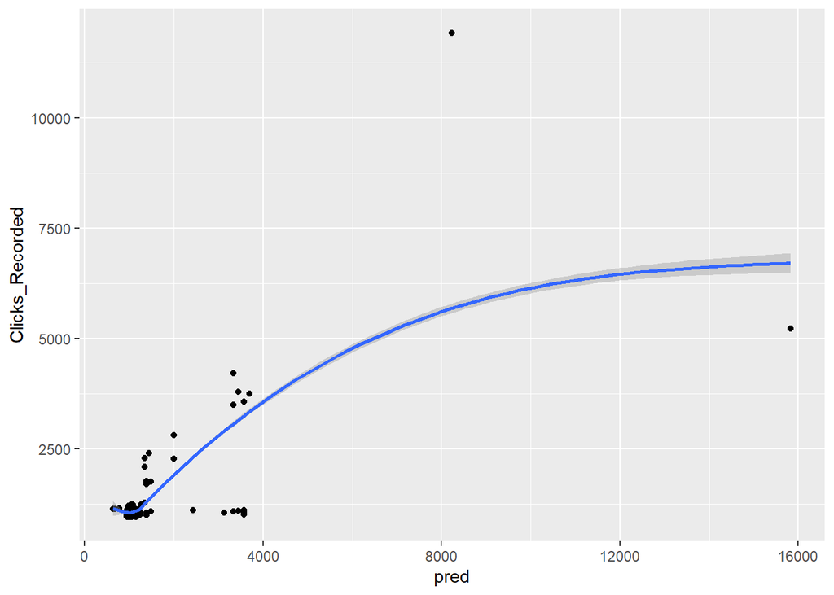

```r
p0 <- modpred$fit
holdout$pred <- p0

ggplot(holdout, aes(pred, Clicks_Recorded)) + geom_point() + geom_smooth()
```

### Results: Conversions

*Out of several models, Model 5 was selected for both the Click Through and Conversion models. Now that we have our models selected, we conducted a train/test split to see how the plots looked for predictions vs actual values.*

*Ultimately, what this says is, we can predict the number of conversions based on the combination of Content_Category, Creative_Product, Creative, Creative_Size, Media_Cost, and the interaction between conversion_rate:Website_Network_Name.*

#### Modeling on Train Set

```r
n <- nrow(df)
shuffled_df <- df[sample(n),]
train_indices <- 1:round(0.7*n)
train <- shuffled_df[train_indices,]
test_indices <- (round(0.7*n) + 1):n
holdout <- shuffled_df[test_indices,]

mod5 <- glm(Units_sold ~ Content_Category+Creative_Product+Creative+Creative_Size+conversion_rate:Website_Network_Name, Media_Cost, data = train, family = "poisson")

1-(mod5$deviance/mod5$null.deviance)
```

```
## [1] 0.9470815
```

```r
summary(mod5)
```

```
##
## Call:
## glm(formula = Units_sold ~ Content_Category + Creative_Product +
##     Creative + Creative_Size + conversion_rate:Website_Network_Name,
##     family = "poisson", data = train, weights = Media_Cost)
##
## Deviance Residuals:
##      Min        1Q    Median        3Q       Max
## -109.781    -0.850    -0.602    -0.447    76.572
##
## Coefficients: (4 not defined because of singularities)
##                                                                        Estimate
## (Intercept)                                                           -17.95894
## Content_CategoryBehavioral Targeting                                    0.68412
## Content_CategoryFront Page                                              4.05605
## Content_CategoryLifestyle                                             -12.93532
## Content_CategoryNews                                                    2.58102
## Content_CategoryPortal Homepage                                         5.96919
## Content_CategoryRetargeting                                             2.85366
## Content_CategoryTechnology                                              0.76372
## Creative_ProductLaptop                                                  0.30532
## CreativeBetter Products                                                -0.15808
## CreativeBetter Than Average                                            -0.25066
## CreativeSave Money                                                     -0.30960
## CreativeSave Money Blue Logo                                           -0.18570
## CreativeSave Money Green Logo $                                        -0.73783
## CreativeSmart tech                                                     -1.67582
## CreativeSuper Value                                                    -0.41268
## Creative_Size160x600                                                   14.21087
## Creative_Size300x250                                                   14.60215
## Creative_Size300x600                                                   -2.80567
## Creative_Size336x280                                                   13.23235
## Creative_Size728x90                                                    13.28635
## conversion_rate:Website_Network_NameAdconion Media Group             3008.93942
## conversion_rate:Website_Network_NameAdvertising.com                   877.12279
## conversion_rate:Website_Network_NameAmazon Media Network             4473.57279
## conversion_rate:Website_Network_NameAmerica Online (AOL)             -585.83614
## conversion_rate:Website_Network_NameCNN                              2686.03186
## conversion_rate:Website_Network_NameCollective Media                 2250.93913
## conversion_rate:Website_Network_Namedeals2buy.com                            NA
```

[output cut: 211 more lines]

```
## conversion_rate:Website_Network_NameWired.com                        ***
## conversion_rate:Website_Network_NameWiredTechnology                  ***
## conversion_rate:Website_Network_NameYahoo! Inc                       ***
## conversion_rate:Website_Network_NameYahoo! Network                   ***
## conversion_rate:Website_Network_NameYahoo! Technology                ***
## ---
## Signif. codes:  0 '***' 0.001 '**' 0.01 '*' 0.05 '.' 0.1 ' ' 1
##
## (Dispersion parameter for poisson family taken to be 1)
##
##     Null deviance: 1995555  on 13813  degrees of freedom
## Residual deviance:  105602  on 13770  degrees of freedom
## AIC: 659663
##
## Number of Fisher Scoring iterations: 15
```

```r
#mod4 <- glm(Units_sold ~ Content_Category+Creative_Product+Creative+ Creative_Size+Website_Network_Name+Impressions_Delivered+Clicks_Recorded, data = train, family = "poisson")
```

```r
head(holdout)
```

```
## # A tibble: 6 x 16
##   Date                Campaign_Name Content_Category Creative_Product Creative
##   <dttm>              <chr>         <fct>            <fct>            <fct>
## 1 2016-08-01 00:00:00 Targeted Con~ Advertising Nets Desktop          Save Mo~
## 2 2016-07-31 00:00:00 Targeted Con~ Advertising Nets Laptop           Best va~
## 3 2016-07-04 00:00:00 Targeted Con~ Retargeting      Laptop           Super V~
## 4 2016-08-07 00:00:00 Targeted Con~ Advertising Nets Laptop           Super V~
## 5 2016-05-21 00:00:00 Targeted Con~ Advertising Nets Desktop          Best va~
## 6 2016-06-02 00:00:00 Targeted Con~ Advertising Nets Laptop           Save Mo~
## # ... with 11 more variables: Creative_Size <fct>, Website_Network_Name <fct>,
## #   Impressions_Delivered <dbl>, Clicks_Recorded <dbl>, Media_Cost <dbl>,
## #   Units_sold <dbl>, ctr <dbl>, conversion_rate <dbl>, cpc <dbl>, cpm <dbl>,
## #   Units_sold2 <dbl>
```

#### Predictions on Holdout

```r
modpred <- predict(object = mod5, newdata=holdout[,c(3:7,10,13)], type="response", se=TRUE)
```

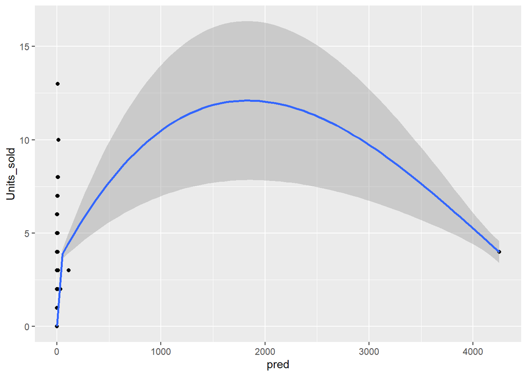

```r
p0 <- modpred$fit
holdout$pred <- p0

ggplot(holdout, aes(pred, Units_sold)) + geom_point() + geom_smooth()
```

### Conclusions

- We decided to use Poisson becasue of three reasons: a) the response variables are counts, b) Units_sold is a rare event where there are a lot of zeroes and a relatively few rows of sales, c) the actual occurences across time are unrelated or iid.
- One flaw is that each time we run the model, we generate a new holdout. We then compare models with different train/test. We could have addressed this by creating the holdout once or using a random seed.
- If this model is used in production, the new unseen data will likely only contain categorical variables. Our model 5 assumes that Media_Cost can be incorporated with this data, along with the ability to use historical conversion_rate with the Website_Network_Name to create a new feature engineered interactive term. The conversion_rate and Website_Network_Name end up not being used as independent variables.
- Finally, after going through this exercise, it dawned on us that we could have approached this as a logistic regression problem if we transformed the conversions variable into either conversion(1) or non-conversion(0). Currently the conversion variable has a range from 0 through 15 but most of the values are already 0 or 1.